# Pravdepodobnost a statistika

Cviceni 10

Alena Cernikova

2025-12-08

### Interval spolehlivosti

```r
library(DescTools)
  # knihovna popisnych statistik

load("Kojeni.RData")
  # nacte databazi Kojeni.RData
  # databaze vytvorena pri zpracovani diplomove prace na PrF UK kolem roku 2000
```

### Interval spolehlivosti pro prumer

Spoctete 95% interval spolehlivosti pro prumer vysky muzu (otcu) kdyz vite, ze rozptyl vysky dospelych muzu je 49.

```r
vyska <- Kojeni$vyskaO

pocet <- length(vyska)
prumer <- mean(vyska)
sm.od <- sqrt(49) # smerodatna odchylka - variabilita
alfa <- 1 - 0.95 # hladina významnosti, velikost chyby, velikost ze se netrefim
kvantil <- qnorm(1 - alfa/2)
  # pri znamem rozptylu se pouziva kvantil normalniho rozdeleni
  # jinak kvantil t-rozdeleni o n-1 stupnich volnosti

# interval spolehlivosti se pocita podle vzorce
#   prumer +- kvantil * sd/odmocnina(n)

cat("\nDolni mez =", prumer - kvantil * sm.od / sqrt(pocet))
```

```
##
## Dolni mez = 177.8837
```

```r
cat("\nHorni mez =", prumer + kvantil * sm.od / sqrt(pocet))
```

```
##
## Horni mez = 180.6415
```

```r
cat("\n\nVypocet pomoci funkce v knihovne DescTools \n")
```

```
##
##
## Vypocet pomoci funkce v knihovne DescTools
```

```r
MeanCI(vyska, sd = sqrt(49))
```

```
##     mean   lwr.ci   upr.ci
## 179.2626 177.8837 180.6415
```

```r
MeanCI(vyska)
```

```
##     mean   lwr.ci   upr.ci
## 179.2626 177.9094 180.6158
```

# Interpretace:

# Se spolehlivosti 95% skutecna stredni hodnota vysky otcu lezi v intervalu od 177.9 do 180.6 cm

- interpretace začíná slovy “se spolehlivostí”
- je v něm parametr střední hodnoty

A jaky je 99% interval spolehlivosti pro vysku matky?

```r
vyska <- Kojeni$vyskaM

pocet <- length(vyska)
prumer <- mean(vyska)
sm.od <- sd(vyska)
alfa <- 1 - 0.99
kvantil <- qt(1 - alfa/2, pocet - 1)
  # kdyz rozptyl neznam a odhaduji ho z dat, pouziva se kvantil t-rozdeleni o n-1 stupnich volnosti

cat("\nDolni mez =", prumer - kvantil*sm.od/sqrt(pocet))
```

```
##
## Dolni mez = 165.3565
```

```r
cat("\nHorni mez =", prumer + kvantil*sm.od/sqrt(pocet))
```

```
##
## Horni mez = 168.5829
```

```r
cat("\n\nVypocet pomoci funkce v knihovne DescTools \n")
```

```
##
##
## Vypocet pomoci funkce v knihovne DescTools
```

```r
MeanCI(vyska, conf.level = 0.99)
```

```
##     mean   lwr.ci   upr.ci
## 166.9697 165.3565 168.5829
```

# Interpretace:

Se spolehlivosti 99% skutecna stredni hodnota vysky matek lezi v intervalu od 165.4 do 168.6 cm

### Spojitost s jednovyberovym testem

Na zaklade 99%-niho intervalu spolehlivosti rozhodnete, zda stredni hodnota vysky matek muze byt: 160 cm, 162 cm, 165 cm, 166 cm, 168 cm, 168.5 cm, 168,7 cm, 169 cm, 180 cm?

### Jednovyberovy test

Pomoci jednovyberoveho t-testu zjistete, zda populacni prumer vysky matek muze byt 169 cm. Pouzijte prikaz t.test(promenna, mu = testovane cislo, alternative = “pozadovana alternativa”) kde pozadovana alternativa muze byt “less”, “greater”, “two.sided” - prednastavena verze, nemusi se zadavat

Stanovene hypotezy: - H0: populacni prumer vysky matek = 169 cm - H1: populacni prumer vysky matek != 169 cm hladina vyznamnosti alfa =

Pokud p-hodnota <= alfa => ZAMITAME H0, plati H1 Pokud p-hodnota > alfa => NEZAMITAME H0

Interpretace vysledku:

predpokladem jednovyberoveho t-testu je normalita dat

```r
vyska <- Kojeni$vyskaM
t.test(vyska, mu = 169, conf.level = 0.99)
```

```
##
##  One Sample t-test
##
## data:  vyska
## t = -3.3061, df = 98, p-value = 0.001323
## alternative hypothesis: true mean is not equal to 169
## 99 percent confidence interval:
##  165.3565 168.5829
## sample estimates:
## mean of x
##  166.9697
```

Na 5% hladine vyznamnosti rozhodnete, zda stredni hodnota porodni hmotnosti deti muze byt 3.5kg. Pouzijte jednovyberovy t-test

```r
hmot <- Kojeni$porHmotnost

t.test(hmot, mu = 3500, conf.level = 0.95)
```

```
##
##  One Sample t-test
##
## data:  hmot
## t = -0.68606, df = 98, p-value = 0.4943
## alternative hypothesis: true mean is not equal to 3500
## 95 percent confidence interval:
##  3381.572 3557.579
## sample estimates:
## mean of x
##  3469.576
```

V jakem rozmezi by se s 90% spolehlivosti mela nachazet stredni hodnota porodni delky deti?

```r
delka <- Kojeni$porDelka

MeanCI(delka, conf.level = 0.90)
```

```
##     mean   lwr.ci   upr.ci
## 50.59596 50.33706 50.85486
```

## Interval spolehlivosti pro rozdil prumeru

Je 95%-ni interval spolehlivosti pro porodni hmotnost stejny u divek a u hochu?

```r
pohlavi <- Kojeni$Hoch
hmot <- Kojeni$porHmotnost
tapply(hmot, pohlavi, MeanCI)
```

```
## $dívka
##     mean   lwr.ci   upr.ci
## 3349.200 3229.326 3469.074
##
## $chlapec
##     mean   lwr.ci   upr.ci
## 3592.408 3468.739 3716.078
```

Intervaly totozne nejsou, ale je mezi divkami a hochy vyznamny rozdil?

Muzeme resit pomoci intervalu spolehlivosti

```r
cat("\n95%-ni interval spolehlivosti \n")
```

```
##
## 95%-ni interval spolehlivosti
```

```r
MeanDiffCI(hmot ~ pohlavi)
```

```
##   meandiff     lwr.ci     upr.ci
## -243.20816 -413.26785  -73.14848
```

```r
  # pokud interval neobsahuje nulu, je vyznamny rozdil ve strednich hodnotach

cat("\n99%-ni interval spolehlivosti \n")
```

```
##
## 99%-ni interval spolehlivosti
```

```r
MeanDiffCI(hmot ~ pohlavi, conf.level=0.99)
```

```
##   meandiff     lwr.ci     upr.ci
## -243.20816 -468.34379  -18.07254
```

```r
  # zjistuji, zda je rozdil vyznamny na 1%-ni hladine vyznamnosti
```

Nebo na to muzeme jit testem Dvouvyberovy t-test ma opet predpoklad normality a navic shodu rozptylu H0: mezi hochy a divkami neni rozdil H1: mezi hochy a divkami je rozdil alfa = 0.05

```r
t.test(hmot ~ pohlavi, var.eq = T)
```

```
##
##  Two Sample t-test
##
## data:  hmot by pohlavi
## t = -2.8391, df = 97, p-value = 0.005512
## alternative hypothesis: true difference in means between group dívka and group chlapec is not equal to 0
## 95 percent confidence interval:
##  -413.22861  -73.18772
## sample estimates:
##   mean in group dívka mean in group chlapec
##              3349.200              3592.408
```

Lisi se prumerna hmotnost pulrocnich deti, ktere byly jeste v pul roce kojeny a tech, co uz kojeny nebyly (promenna Koj24)?

```r
hmot <- Kojeni$hmotnost
skupina <- Kojeni$Koj24
```

### Interval spolehlivosti pro pravdepodobnost (podil)

Spoctete a interpretujte 95%-ni interval spolehlivosti pro podil otcu pritomnych u porodu

```r
otec <- Kojeni$Otec
table(otec)
```

```
## otec
## nepřítomen   přítomen
##         63         36
```

```r
  # u porodu bylo pritomno 36 otcu
round(prop.table(table(otec)), 4) * 100
```

```
## otec
## nepřítomen   přítomen
##      63.64      36.36
```

```r
  # coz je 36.36%
```

Vypocet intervalu spolehlivosti

```r
# rucni vypocet
p <- prop.table(table(otec))[2]
n <- length(otec)
alpha <- 0.05
q.n <- qnorm(1 - alpha/2)
  # zde se pouziva kvantil normalniho rozdeleni vzdy

cat("\nDolni mez = ", p - q.n*sqrt(p*(1-p)/n))
```

```
##
## Dolni mez =  0.2688782
```

```r
cat("\nHorni mez = ", p + q.n*sqrt(p*(1-p)/n))
```

```
##
## Horni mez =  0.4583946
```

```r
  # se spolehlivosti 95% skutecny podil otcu pritomnych u porodu se nachazi mezi 26.9% a 45.8%

cat("\n\n95%-ni interval spolehlivosti pomoci prednastavene funkce\n")
```

```
##
##
## 95%-ni interval spolehlivosti pomoci prednastavene funkce
```

```r
BinomCI(table(otec)[2], sum(table(otec)), method = "wald")
```

```
##            est    lwr.ci    upr.ci
## [1,] 0.3636364 0.2688782 0.4583946
```

Spoctete 90%-ni interval spolehlivosti pro podil deti, ktere byly jeste v pul roce kojeny (promenna Koj24)

```r
Kojene <- Kojeni$Koj24
(tab <- table(Kojene))
```

```
## Kojene
##  1  2
## 71 28
```

Spojeni s testem Test o hodnote podilu Muze byt skutecny podil kojenych deti 50%? (kod 2) H0: H1: hladina vyznamnosti alfa = Pouzijte funkci prop.test(pocet uspechu, pocet pokusu, p = nulova hypoteza, alternative = “alternativa”)

```r
prop.test(tab[2], sum(tab), p = 0.5)
```

```
##
##  1-sample proportions test with continuity correction
##
## data:  tab[2] out of sum(tab), null probability 0.5
## X-squared = 17.818, df = 1, p-value = 2.43e-05
## alternative hypothesis: true p is not equal to 0.5
## 95 percent confidence interval:
##  0.1991153 0.3836678
## sample estimates:
##         p
## 0.2828283
```

Intervalu spolehlivosti je vice prop.test pouziva vystupy ze score testu

### Interval spolehlivosti pro rozdil podilu

Jak velky je rozdil v podilu otcu pritomnych u porodu mezi Prahou a Kladnem?

```r
mesto <- Kojeni$Porodnice
(tab <- table(otec, mesto))
```

```
##             mesto
## otec         Praha okresní
##   nepřítomen    53      10
##   přítomen      17      19
```

Odhad rozdilu podilu a interval spolehlivosti

```r
cat("\nPodil pritomnych otcu v Praze =", tab[2,1]/(tab[1,1] + tab[2,1]))
```

```
##
## Podil pritomnych otcu v Praze = 0.2428571
```

```r
cat("\nPodil pritomnych otcu v Kladne =", tab[2,2]/(tab[1,2] + tab[2,2]))
```

```
##
## Podil pritomnych otcu v Kladne = 0.6551724
```

```r
cat("\nRozdil techto podilu v Praze a na Kladne =", tab[2,1]/(tab[1,1] + tab[2,1]) - tab[2,2]/(tab[1,2] + tab[2,2]))
```

```
##
## Rozdil techto podilu v Praze a na Kladne = -0.4123153
```

```r
cat("\n\n95%-ni interval spolehlivosti pomoci prednastavene funkce\n")
```

```
##
##
## 95%-ni interval spolehlivosti pomoci prednastavene funkce
```

```r
BinomDiffCI(x1 = tab[2,1], n1 = tab[1,1] + tab[2,1], x2 = tab[2,2], n2 = tab[1,2] + tab[2,2], method ="wald")
```

```
##             est     lwr.ci    upr.ci
## [1,] -0.4123153 -0.6123586 -0.212272
```

Je rozdil mezi podilem pritomnych otcu v Praze a na Kladne vyznamny? Resime testem H0: H1: hladina vyznamnosti alfa =

```r
prop.test(c(tab[2,1], tab[2,2]), c(tab[1,1] + tab[2,1], tab[1,2] + tab[2,2]))
```

```
##
##  2-sample test for equality of proportions with continuity correction
##
## data:  c(tab[2, 1], tab[2, 2]) out of c(tab[1, 1] + tab[2, 1], tab[1, 2] + tab[2, 2])
## X-squared = 13.335, df = 1, p-value = 0.0002605
## alternative hypothesis: two.sided
## 95 percent confidence interval:
##  -0.6367428 -0.1878877
## sample estimates:
##    prop 1    prop 2
## 0.2428571 0.6551724
```

Spoctete 99% interval spolehlivosti pro rozdil podilu v pul roce kojenych deti (kod 2) v Praze a na Kladne.

```r
kojene <- Kojeni$Koj24
mesto <- Kojeni$Porodnice
(tab <- table(kojene, mesto))
```

```
##       mesto
## kojene Praha okresní
##      1    49      22
##      2    21       7
```

Bootstrapovy interval spolehlivosti pro prumer Vyse zmineny interval spolehlivosti pro prumer funguje dobre u dat s priblizne normalnim rozdelenim u dat s vyraznymi odchylkami od normality je mozne pouzit napr. bootstrapovy interval spolehlivosti

Spoctete 95%-ni interval spolehlivosti pro pocet tydnu, po ktere byly deti plne kojeny (promenna trvani)

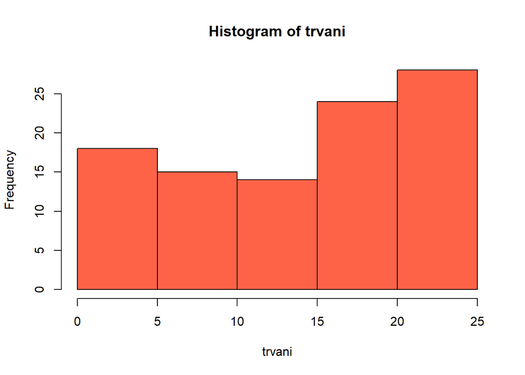

```r
trvani <- Kojeni$trvani
hist(trvani, col = "tomato")
```

```r
cat("\nKlasicky 95%-ni interval spolehlivosti pro prumer\n")
```

```
##
## Klasicky 95%-ni interval spolehlivosti pro prumer
```

```r
MeanCI(trvani)
```

```
##     mean   lwr.ci   upr.ci
## 14.43434 12.84843 16.02026
```

```r
cat("\n\nBootstrapovy 95%-ni interval spolehlivosti pro prumer\n")
```

```
##
##
## Bootstrapovy 95%-ni interval spolehlivosti pro prumer
```

```r
MeanCI(trvani, method = "boot")
```

```
##     mean   lwr.ci   upr.ci
## 14.43434 12.96970 16.00000
```

Pro asymetricke rozdeleni muze byt bootstrapovy interval mirne asymetricky

Pro symetricke rozdeleni se od klasickeho lisi jen minimalne Interval spolehlivosti pro vysku otce

```r
vyska <- Kojeni$vyskaO

cat("\nKlasicky 95%-ni interval spolehlivosti pro prumer\n")
```

```
##
## Klasicky 95%-ni interval spolehlivosti pro prumer
```

```r
MeanCI(vyska)
```

```
##     mean   lwr.ci   upr.ci
## 179.2626 177.9094 180.6158
```

```r
cat("\n\nBootstrapovy 95%-ni interval spolehlivosti pro prumer\n")
```

```
##
##
## Bootstrapovy 95%-ni interval spolehlivosti pro prumer
```

```r
MeanCI(vyska, method = "boot")
```

```
##     mean   lwr.ci   upr.ci
## 179.2626 177.9798 180.6566
```

```r
BootCI(vyska, FUN = mean)
```

```
##     mean   lwr.ci   upr.ci
## 179.2626 177.9151 180.6065
```

Rucni vypocet pro vysku otce

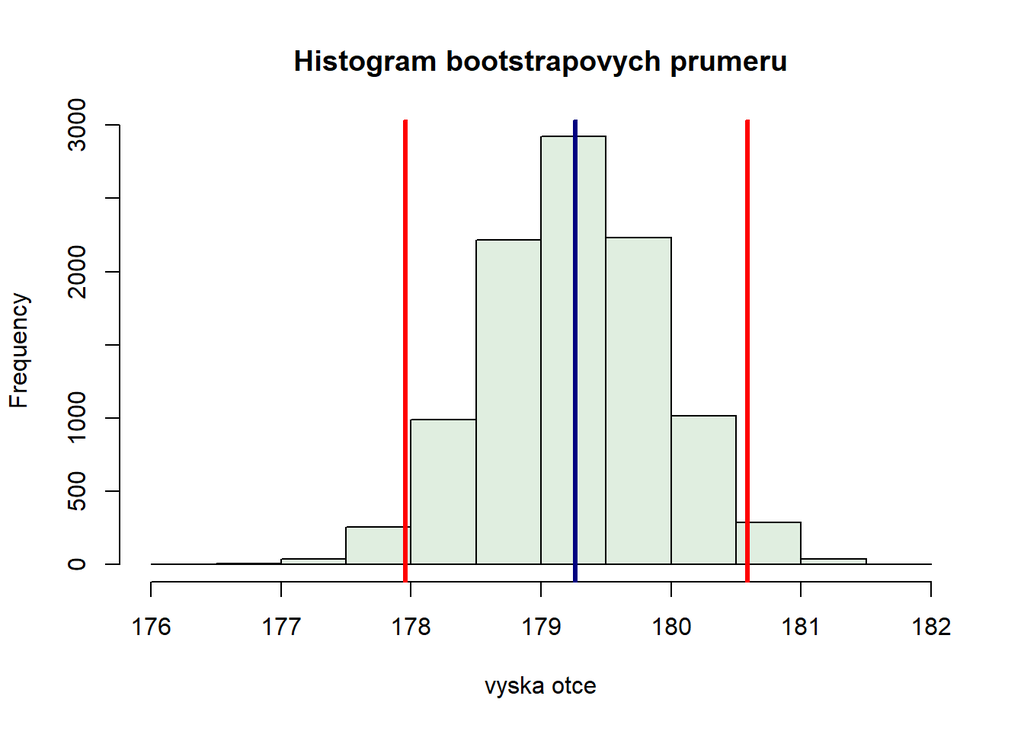

```r
boots <- list()
B <- 10000
for(i in 1:B) boots[[i]] <- sample(vyska, replace = TRUE)
  # bootstrapove vybery
means <- unlist(lapply(boots, mean))
  # bootstrapove prumery

hist(means, col = "honeydew2", xlab = "vyska otce",
     main = "Histogram bootstrapovych prumeru")
abline(v = mean(vyska), lwd = 3, col = "navy")
abline(v = quantile(means, probs = c(0.025, 0.975)), lwd = 3, col = "red")
```

```r
cat("\nBootstrapovy interval spolehlivosti\n")
```

```
##
## Bootstrapovy interval spolehlivosti
```

```r
c(mean = mean(vyska), quantile(means, probs = c(0.025, 0.975)))
```

```
##     mean     2.5%    97.5%
## 179.2626 177.9596 180.5859
```